# National MENTOR Program Report

Samuel McQuillin

Heather McDaniel

University of South Carolina

# Agency Questions

## What position do you hold in the organization/agency?

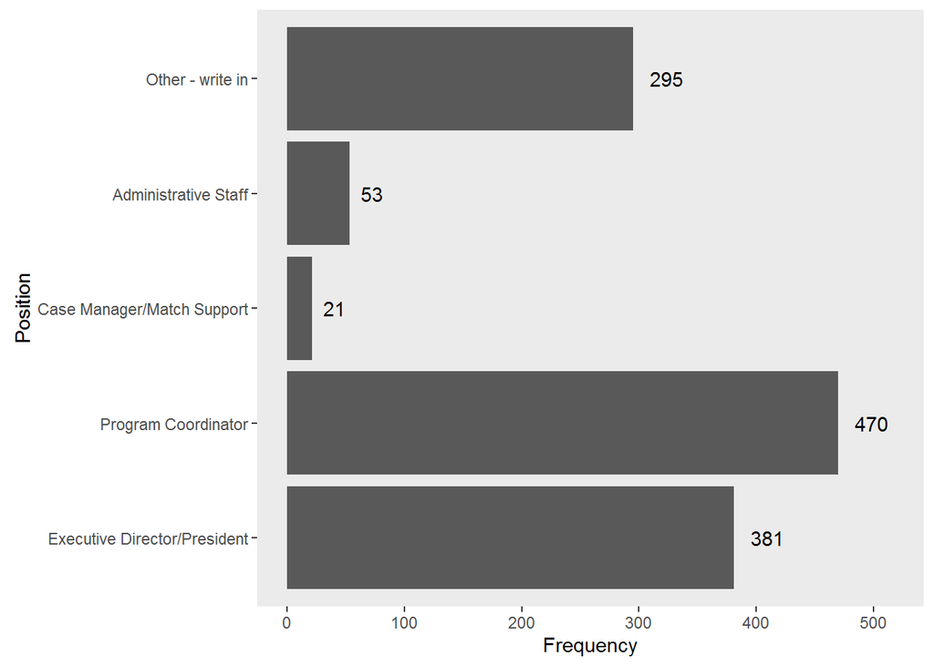

## Which state is your organization/agency based in?

| State | Frequency |
| --- | --- |
| Alabama | 2 |
| Arizona | 6 |
| Arkansas | 1 |
| California | 49 |
| Colorado | 66 |
| Connecticut | 2 |
| Delaware | 1 |
| District of Columbia | 6 |
| Florida | 33 |
| Georgia | 194 |
| Hawaii | 1 |
| Idaho | 2 |
| Illinois | 136 |
| Indiana | 19 |
| Iowa | 72 |
| Kansas | 15 |
| Kentucky | 3 |
| Louisiana | 2 |
| Maine | 1 |
| Maryland | 62 |
| Massachusetts | 6 |
| Michigan | 24 |
| Minnesota | 43 |
| Mississippi | 3 |
| Missouri | 3 |
| Montana | 6 |
| Nebraska | 17 |
| New Hampshire | 2 |
| New Jersey | 13 |
| New Mexico | 2 |
| New York | 36 |
| North Carolina | 11 |
| North Dakota | 5 |
| Ohio | 13 |
| Oklahoma | 2 |
| Oregon | 20 |
| Pennsylvania | 101 |
| Rhode Island | 35 |
| South Carolina | 7 |
| South Dakota | 2 |
| Tennessee | 37 |
| Texas | 34 |
| Utah | 1 |
| Vermont | 34 |
| Virginia | 38 |
| Washington | 36 |
| West Virginia | 2 |
| Wisconsin | 14 |
| Wyoming | 2 |

## Our agency is a…

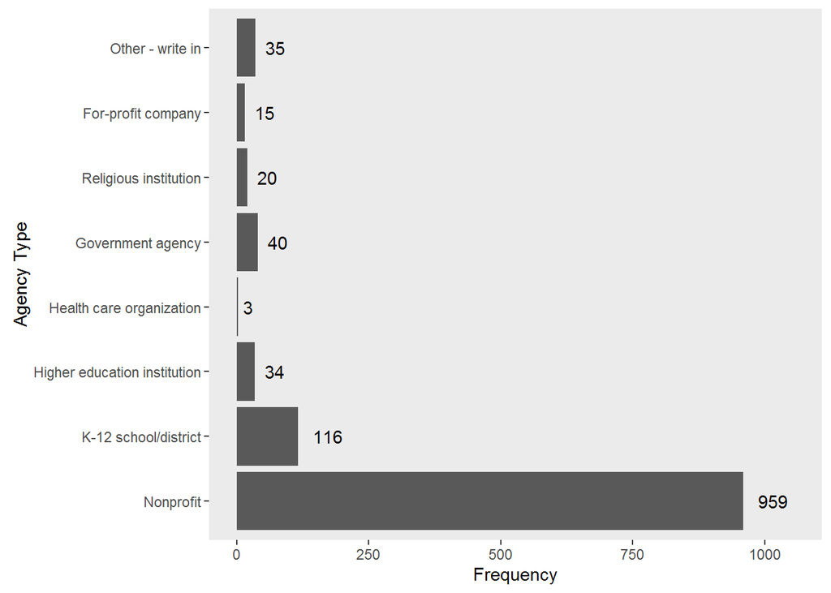

## How many individual mentoring programs does your agency operate?

**Median Number of Programs:** 1  
**Modal Number of Programs:** 1  
**Mean Number of Programs:** 2.58

## How many of these mentoring programs would you like to report on in this survey?

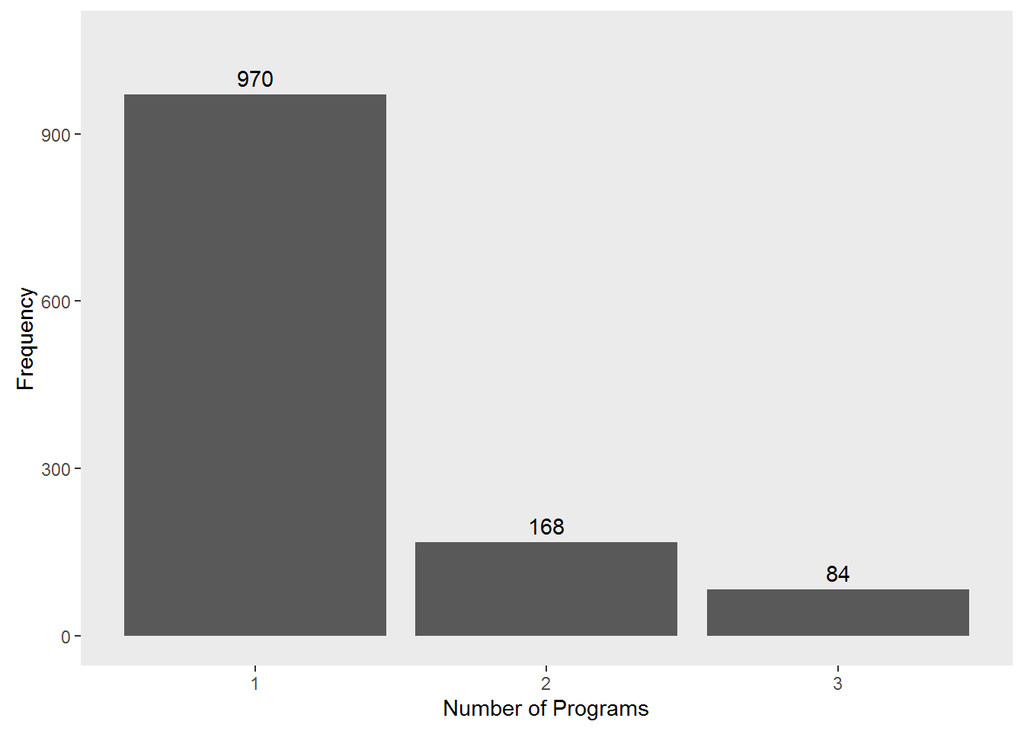

## What other non-mentoring services or programs does your agency (or a larger parent organization you are under) provide to youth and/or families?

| **Service** | **Frequency** | **Proportion** |
| --- | --- | --- |
| Academic support programs | 592 | 0.48 |
| After school/daycare programs | 396 | 0.32 |
| Case management | 337 | 0.28 |
| College and career readiness | 537 | 0.44 |
| Drop in center/homeless/runaway services | 105 | 0.09 |
| Education (Primary or Secondary school) | 291 | 0.24 |
| Empowerment/leadership development | 572 | 0.47 |
| Foster care or services for foster youth | 123 | 0.1 |
| Independent living/transition-aged youth services | 116 | 0.09 |
| Medical/healthcare services | 91 | 0.07 |
| Mental health prevention and wellness | 226 | 0.18 |
| Outpatient psychiatric treatment | 37 | 0.03 |
| Positive youth development | 799 | 0.65 |
| Pregnancy prevention | 127 | 0.1 |
| Psychological counseling | 142 | 0.12 |
| Residential or inpatient psychiatric treatment | 32 | 0.03 |
| Service learning/volunteerism | 548 | 0.45 |
| Services for juvenile justice-involved youth | 256 | 0.21 |
| Services for pregnant and parenting teens | 151 | 0.12 |
| Services for youth with disabilities | 194 | 0.16 |
| Substance use disorder prevention or treatment | 155 | 0.13 |
| Violence prevention | 221 | 0.18 |
| Workforce development | 314 | 0.26 |
| Other - Write In | 206 | 0.17 |

## Please select your agency’s most successful recruitment strategies for mentors.

| **Recruitment Strategy** | **Frequency** | **Proportion** |
| --- | --- | --- |
| Media/Public relations | 285 | 0.23 |
| National Mentoring Month events and promotions | 54 | 0.04 |
| Online outreach (Facebook, program website, etc.) | 409 | 0.33 |
| Community events and in-person presentations by staff | 640 | 0.52 |
| Referrals from community partners | 390 | 0.32 |
| Referrals from the Mentoring Connector database | 49 | 0.04 |
| Referrals from our local Mentoring Partnership | 36 | 0.03 |
| Volunteer Centers and other volunteer organizations | 92 | 0.08 |
| Word-of-mouth from current or former mentors | 816 | 0.67 |
| Other - Write In | 159 | 0.13 |

## How familiar is your agency with the current 4th edition of the Elements of Effective Practice for Mentoring?

| Familiarity | Proportion |
| --- | --- |
| We use it regularly in our work | 0.26 |
| We use it a bit in our work | 0.20 |
| We are aware of the new edition but are not using it | 0.12 |
| We are unaware of the new edition | 0.13 |
| We are not using the new edition but have used the 3rd edition in the past | 0.05 |
| We are not using any edition of this publication in our work | 0.24 |
| *Sample size:* 1205 |  |

## In the last year, has your agency worked with a training/technical assistance provider or an intermediary support organization to improve the quality and capacity of your mentoring services?

| **Recruitment Strategy** | **Frequency** | **Proportion** |
| --- | --- | --- |
| MENTOR: The National Mentoring Partnership | 262 | 0.21 |
| State or Local Mentoring Partnership | 439 | 0.36 |
| National Mentoring Resource Center | 100 | 0.08 |
| United Way or other funding agency | 189 | 0.15 |
| For-profit consulting firm | 49 | 0.04 |
| Nonprofit consulting firm | 109 | 0.09 |
| Other - Write In | 0 | 0 |

## Please choose the main challenges or areas of need for which you think your agency’s mentoring programs might benefit from additional support.

| **Challenge Area** | **Frequency** | **Proportion** |
| --- | --- | --- |
| Blending mentoring with other services | 169 | 0.14 |
| Cultural perspectives in service design and delivery | 174 | 0.14 |
| Developing meaningful activities for mentors and youth | 283 | 0.23 |
| Fundraising/grantwriting* | 534 | 0.44 |
| General program design/theory of change | 97 | 0.08 |
| Integrating youth development principles | 81 | 0.07 |
| Making strong mentor-mentee matches | 179 | 0.15 |
| Mentor recruitment | 579 | 0.47 |
| Mentor training (including curriculum development) | 328 | 0.27 |
| Offering mentoring in rural settings | 119 | 0.1 |
| Parent/family engagement | 403 | 0.33 |
| Partnership development | 156 | 0.13 |
| Professional development of staff | 191 | 0.16 |
| Program evaluation/data collection | 299 | 0.24 |
| Program sustainability/growth | 335 | 0.27 |
| Supporting mentor-mentee matches | 179 | 0.15 |

## What evaluation activities has your agency engaged in for your mentoring services in the past five years?

| **Evaluation** | **Frequency** | **Proportion** |
| --- | --- | --- |
| Qualitative evaluation | 838 | 0.69 |
| Implementation evaluation | 551 | 0.45 |
| Outcome evaluation | 607 | 0.5 |
| Experimental or quasi-experimental evaluation | 107 | 0.09 |
| Return-on-investment study | 51 | 0.04 |
| We haven’t engaged in any evaluation activities | 173 | 0.14 |
| Other - Write In | 68 | 0.06 |

```
Key:

Qualitative evaluation:
examines participant experiences through interviews, end-of-year satisfaction
surveys, case notes, focus groups, or other data sources

Implementation evaluation:
examines how well or efficiently services were delivered to participants, such
as tracking mentor-mentee meetings, participation in trainings, etc.

Outcome evaluation:
examines changes in participants served using pre-post data collection

Experimental or quasi-experimental evaluation:
compares mentored youth to a comparison or "control" group of non-mentored youth

Return-on-investment study:
examines long-term impacts from an economic perspective, often in relation to program costs
```

## Who plays a role in planning and implementing your agency’s mentoring-related evaluation efforts?

| **Stakeholder** | **Frequency** | **Proportion** |
| --- | --- | --- |
| Executive Director/Program Coordinator | 959 | 0.78 |
| Staff evaluation specialist (internal staff) | 358 | 0.29 |
| Professional external evaluator* | 134 | 0.11 |
| Funding agency or philanthropy | 99 | 0.08 |
| Our local Mentoring Partnership | 88 | 0.07 |
| School or district staff | 145 | 0.12 |
| We have not done any evaluation work | 105 | 0.09 |
| Other - Write In | 135 | 0.11 |

# Program Questions

## The primary model of mentoring for this program is…

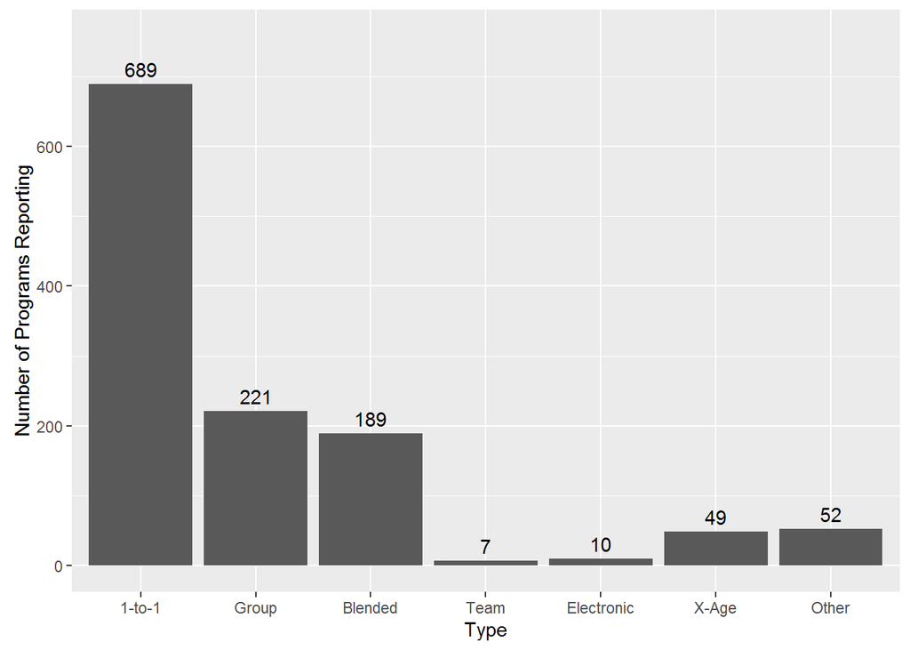

## How many years has this program been offering mentoring?

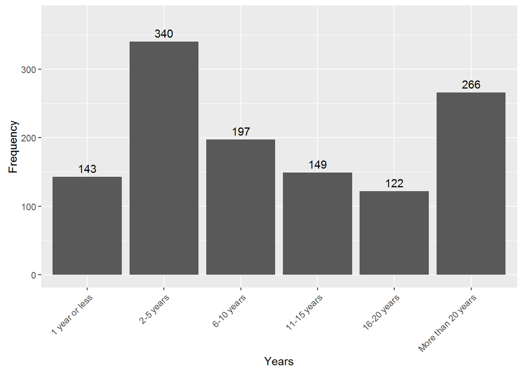

## Where do this program’s matches typically meet?

| **Meeting Place** | **Frequency** | **Proportion** |
| --- | --- | --- |
| Out in the general community | 576 | 0.47 |
| K-12 school (during day) | 391 | 0.32 |
| Afterschool program | 334 | 0.27 |
| Higher education institution | 69 | 0.06 |
| Community center | 168 | 0.14 |
| Nonprofit organization | 301 | 0.25 |
| Religious facility | 87 | 0.07 |
| Juvenile justice facility | 36 | 0.03 |
| Other residential facility | 40 | 0.03 |
| Worksite | 63 | 0.05 |
| Online | 36 | 0.03 |
| Other - Write In (Required) | 121 | 0.1 |

## Please choose the core goals or youth outcome areas for this mentoring program.

| **Focus** | **Frequency** | **Proportion** |
| --- | --- | --- |
| Academic enrichment | 434 | 0.36 |
| Career exploration | 317 | 0.26 |
| Civic engagement | 103 | 0.08 |
| College access | 213 | 0.17 |
| Educational Attainment | 189 | 0.15 |
| Family support | 111 | 0.09 |
| General youth development | 605 | 0.5 |
| Identity development | 74 | 0.06 |
| Juvenile justice/re-entry | 47 | 0.04 |
| Leadership development | 255 | 0.21 |
| Life skills/social skills | 682 | 0.56 |
| Literacy | 91 | 0.07 |
| Mental health and well-being | 131 | 0.11 |
| Positive health behaviors | 193 | 0.16 |
| Pregnancy prevention | 14 | 0.01 |
| Providing a caring adult relationship | 534 | 0.44 |
| Recreational activities | 155 | 0.13 |
| Resiliency | 137 | 0.11 |
| STEM education | 68 | 0.06 |
| Substance use/abuse | 35 | 0.03 |
| Violence prevention | 58 | 0.05 |
| Other | 93 | 0.08 |

## What is the expected frequency for mentors to meet with their mentees in this program?

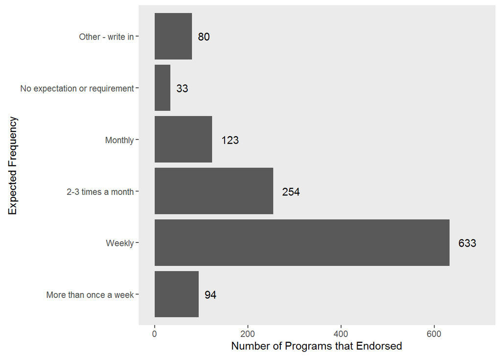

## How many total hours per month are mentors expected to meet with their mentees in this program?

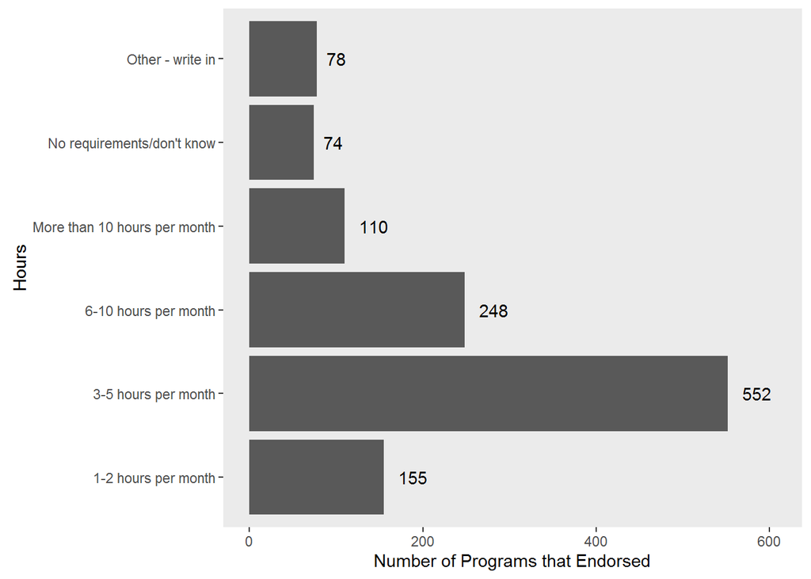

## What is the minimum length of commitment (per match) for mentors in this program?

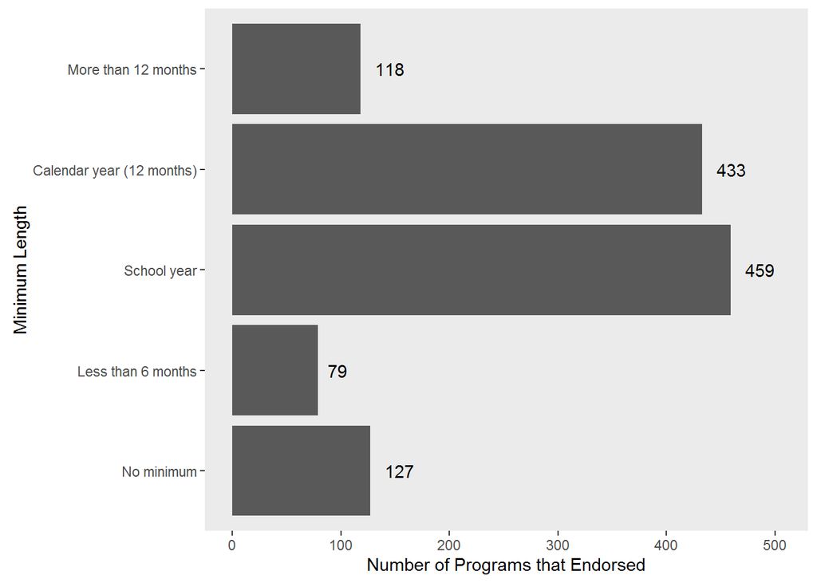

## In the last year, roughly what percentage of this program’s matches met the minimum length of commitment?

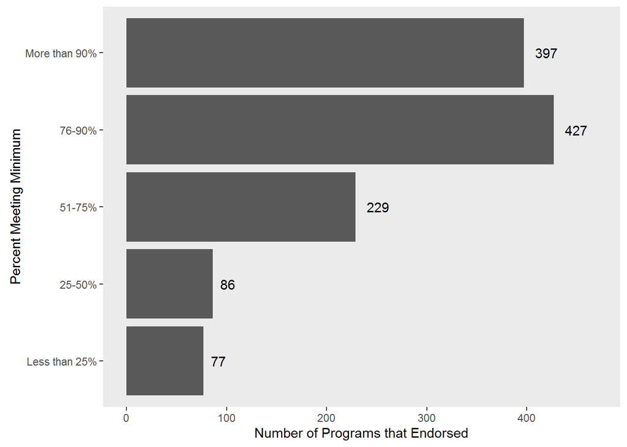

## For those matches that ended early (before the minimum length of commitment), please choose the most common reasons.

| **Reason** | **Frequency** | **Proportion** |
| --- | --- | --- |
| Mentor change in life circumstances | 630 | 0.52 |
| Mentee change in life circumstances | 629 | 0.51 |
| Mentor unfulfilled/unrealistic expectations | 170 | 0.14 |
| Mentee unfulfilled/unrealistic expectations | 112 | 0.09 |
| Mentor did not feel youth needed them | 45 | 0.04 |
| Cultural differences | 18 | 0.01 |
| Family interference/lack of support | 166 | 0.14 |
| Lack resources to provide match support | 100 | 0.08 |
| Unknown | 100 | 0.08 |
| Other | 150 | 0.12 |

## Please estimate the current average length of matches in months for this program.

Median Duration: 12  
Modal Duration: 12  
Mean Duration: 15.9

# Budget & Staffing Questions

## How many FTE (full time equivalent) staff positions implement this specific mentoring program?

## Program Director/Coordinator

### -Median FTE: 1

### -Modal FTE: 1

### -Mean FTE: 2.34

## Other paid program staff positions (trainers, match support specialists, etc.)

### -Median FTE: 1

### -Modal FTE: 1

### -Mean FTE: 3.65

## Volunteer staff positions (not mentors)

### -Median FTE: 1

### -Modal FTE: 0

### -Mean FTE: 6.26

## AmeriCorps/VISTA/other National Service positions (not mentors)

### -Median FTE: 1

### -Modal FTE: 0

### -Mean FTE: 3.06

## Other Staffing

### -Median FTE: 0.75

### -Modal FTE: 0

### -Mean FTE: 3.07

## Compared to the previous program year, did the total number of FTE mentoring staff positions for this specific program.

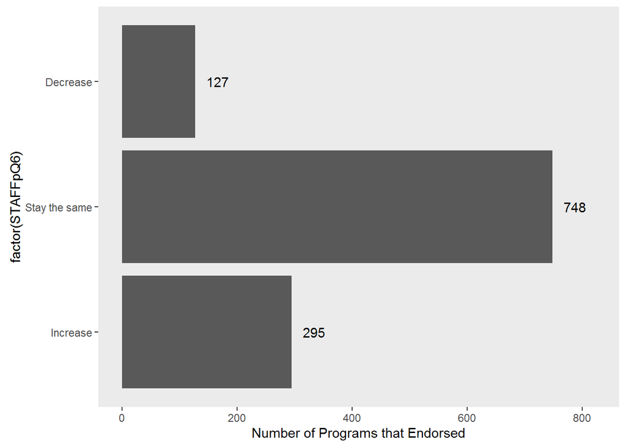

## What is the current annual budget for this specific mentoring program’s services?

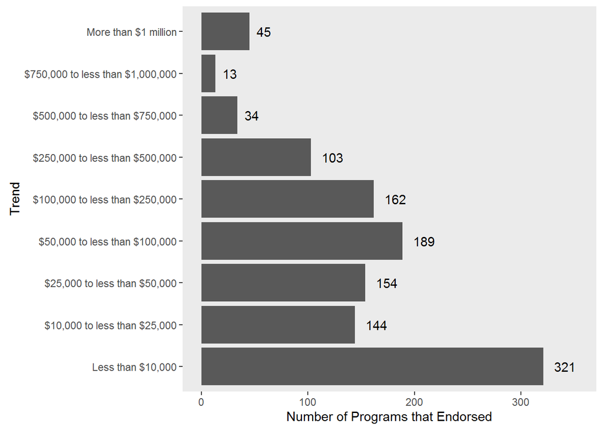

## Over the last three years, this budget has.

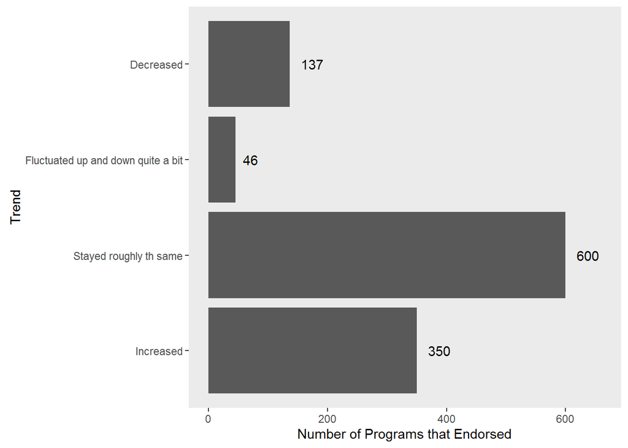

## Sources of Funding by Percentage

### Please estimate the percentage of current funding for this specific mentoring program that has come from the following source: Federal government grants

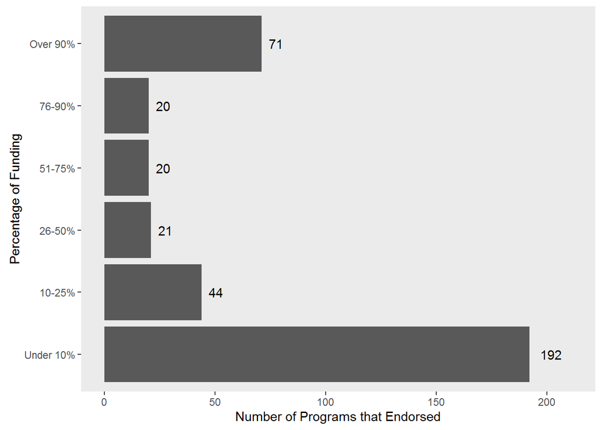

### Please estimate the percentage of current funding for this specific mentoring program that has come from the following source: State government grants

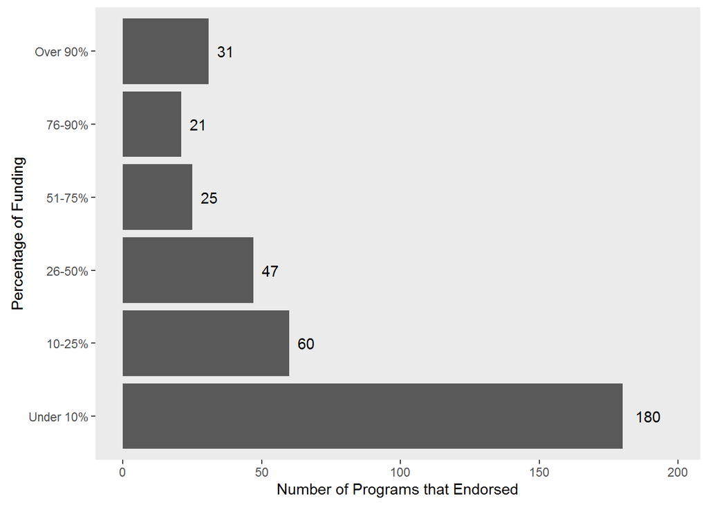

### Please estimate the percentage of current funding for this specific mentoring program that has come from the following source: County or municipal grants

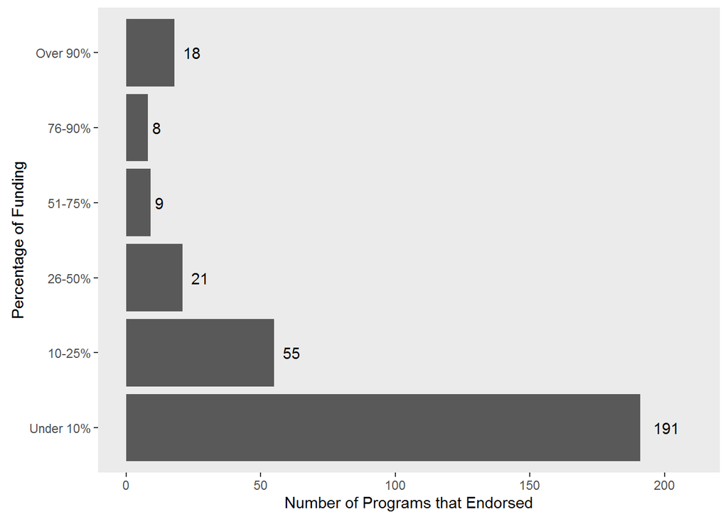

### Please estimate the percentage of current funding for this specific mentoring program that has come from the following source: K-12 school/district/LEA/ESD grants

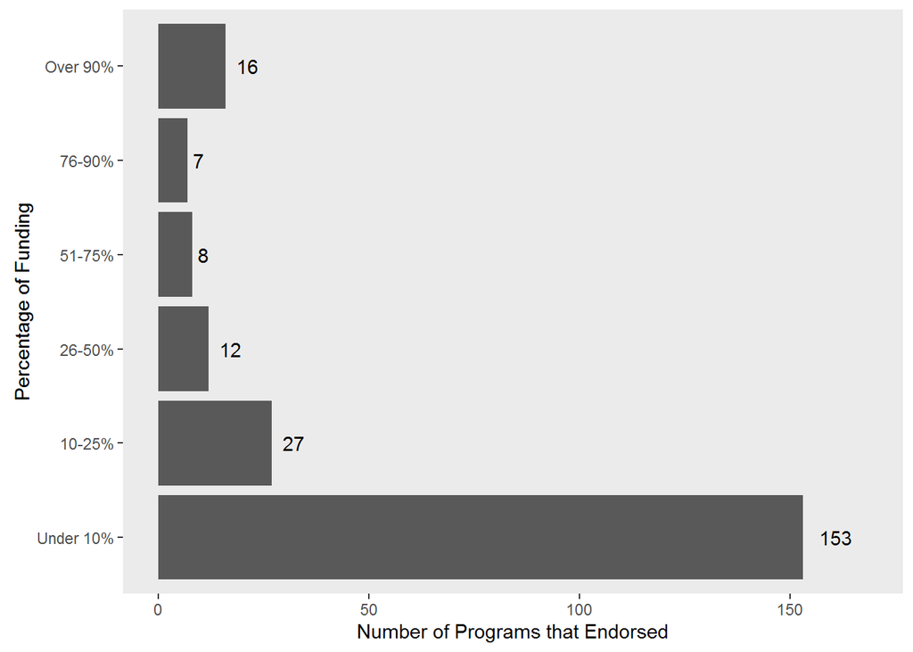

### Please estimate the percentage of current funding for this specific mentoring program that has come from the following source: Private foundation grants

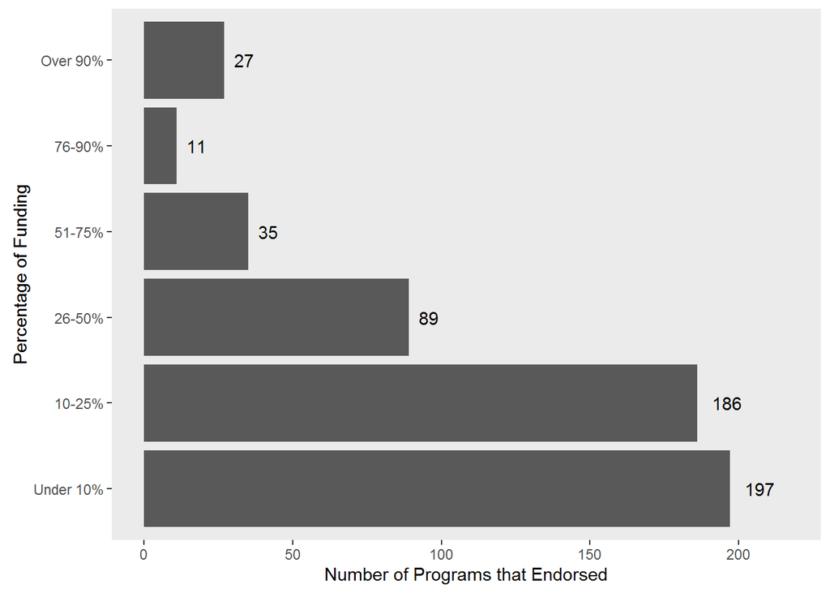

### Please estimate the percentage of current funding for this specific mentoring program that has come from the following source: Community foundation grants

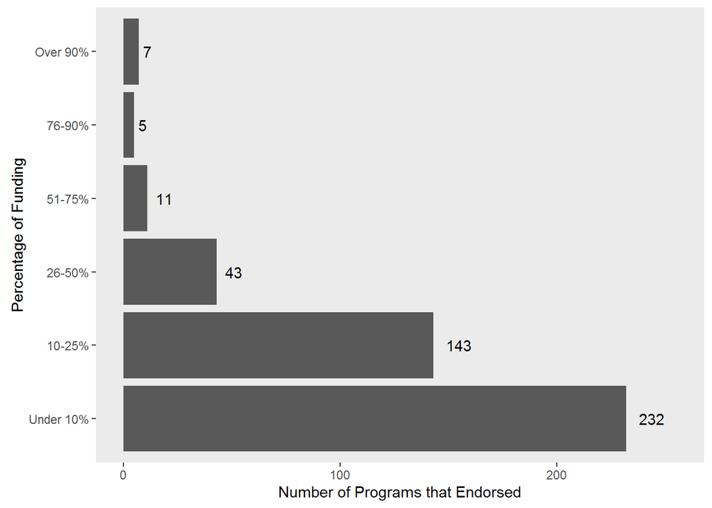

### Please estimate the percentage of current funding for this specific mentoring program that has come from the following source: United Way grants

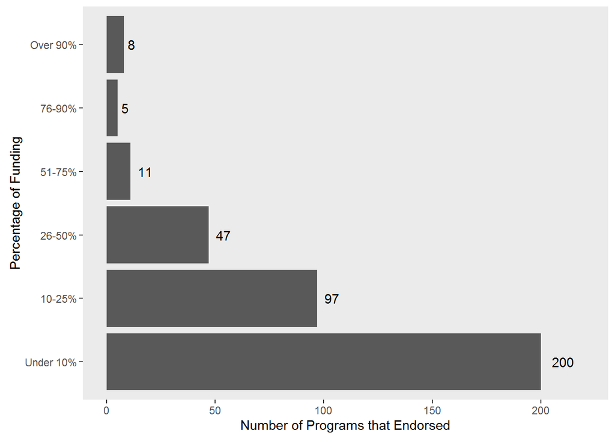

### Please estimate the percentage of current funding for this specific mentoring program that has come from the following source: Business or corporate donations

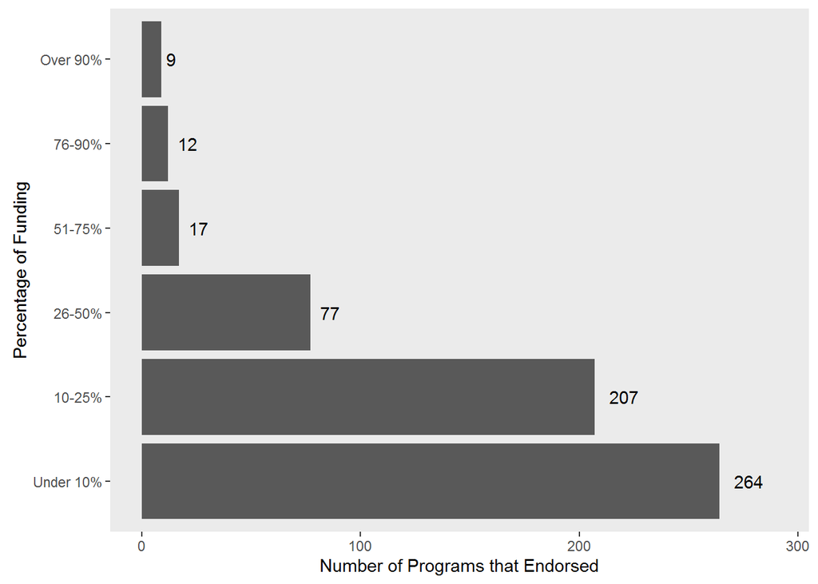

### Please estimate the percentage of current funding for this specific mentoring program that has come from the following source: Private philanthropy donations

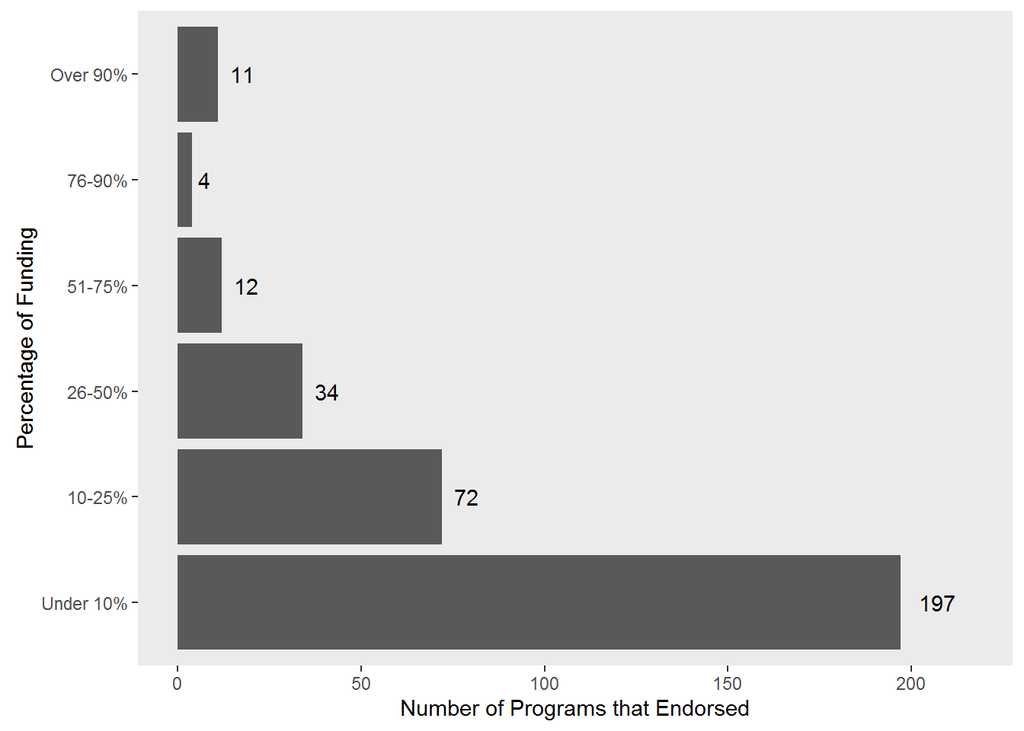

### Please estimate the percentage of current funding for this specific mentoring program that has come from the following source: Individual donations/bequests

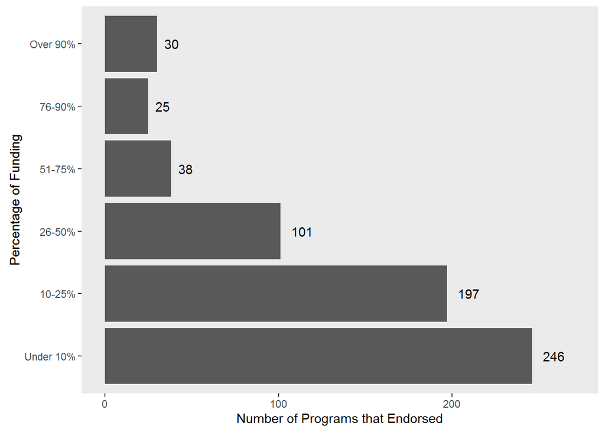

### Please estimate the percentage of current funding for this specific mentoring program that has come from the following source: Fundraising events

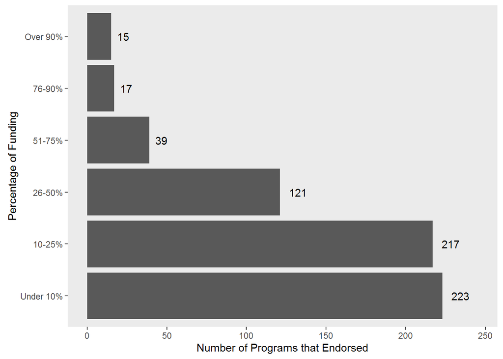

### Please estimate the percentage of current funding for this specific mentoring program that has come from the following source: Earned income/contracted income

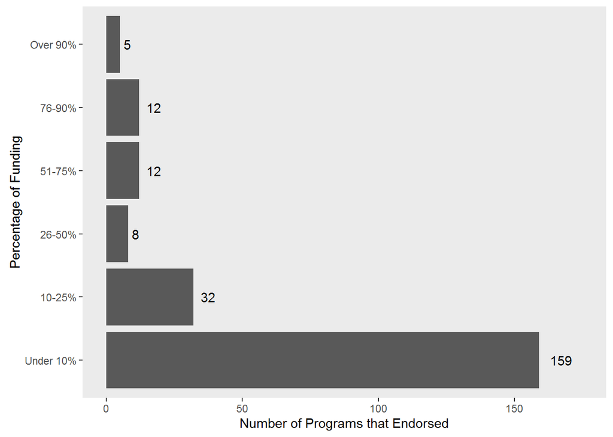

### Please estimate the percentage of current funding for this specific mentoring program that has come from the following source: Mentoring Partnership support

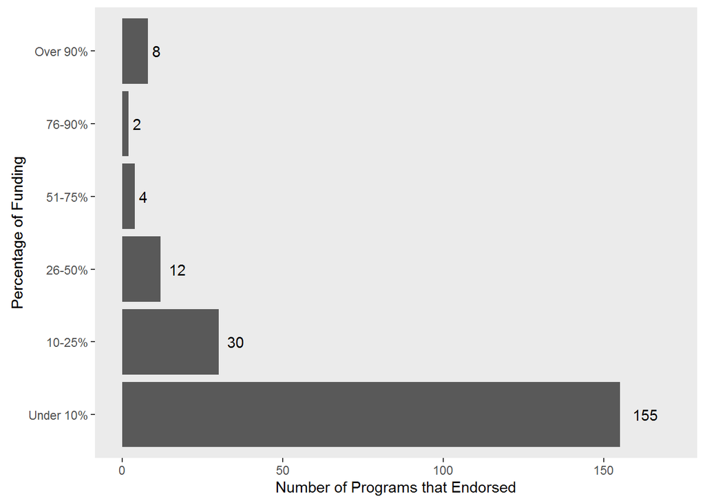

### Please estimate the percentage of current funding for this specific mentoring program that has come from the following source: Other

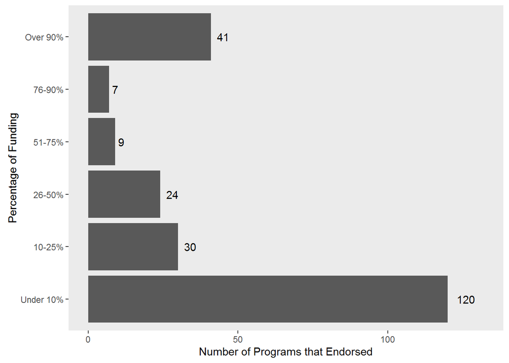

# Characteristics of Youth Served by the Program

## In the last year, how many youth were served (placed in a match or otherwise supported) by this mentoring program?

### Males

### -Median: 30

### -Mean: 139.19

### Females

### -Median: 30

### -Mean: 139.06

### Transgender males

### -Median: 0

### -Mean: 8.06

### Transgender females

### -Median: 0

### -Mean: 0.4

## Ages of youth served - Please estimate the percentage of youth by this program that are the following ages.

### 5 - 10 years old

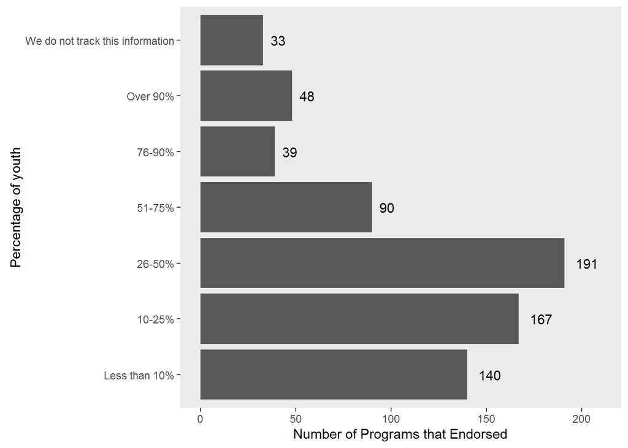

### 11-14 years old

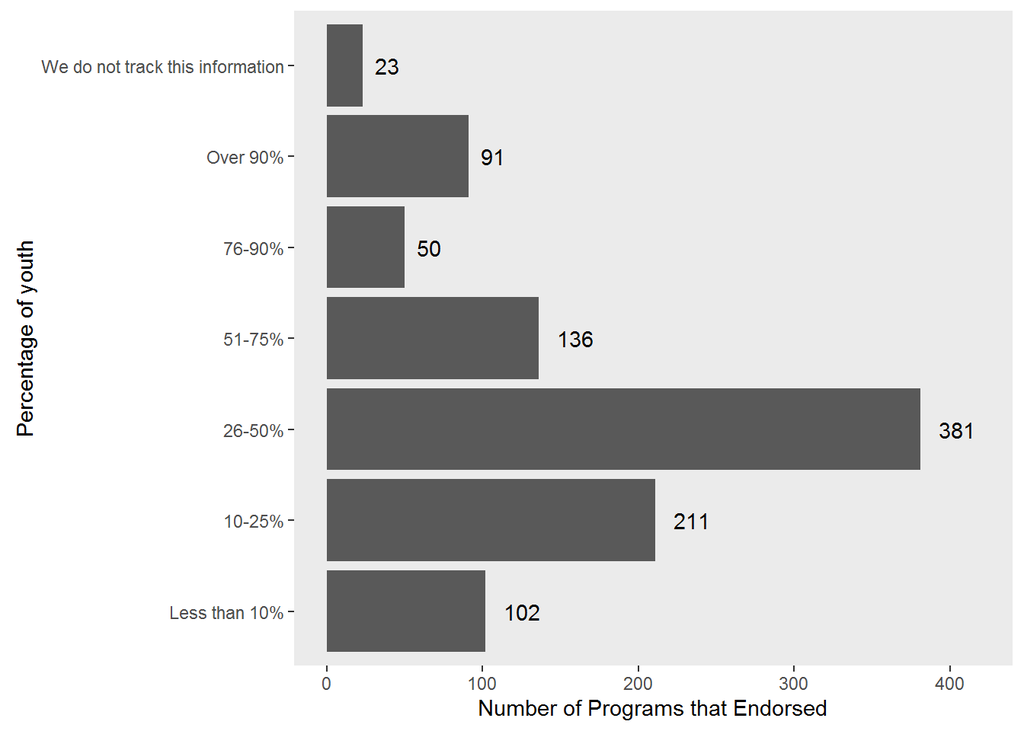

### 15-18 years old

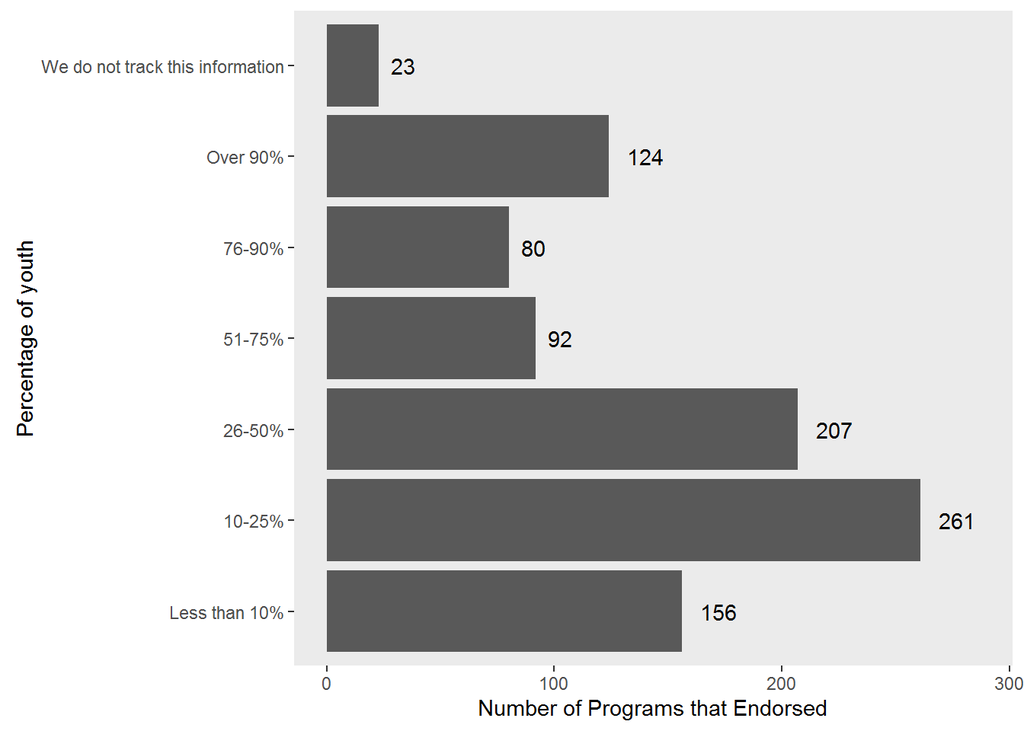

### 19-24 years old

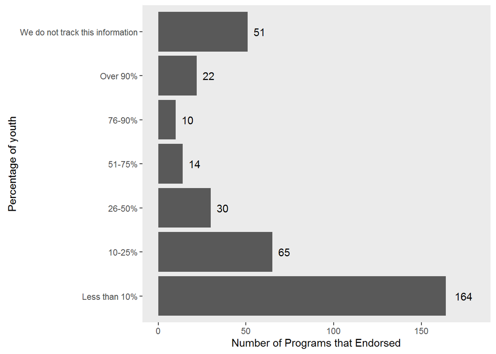

### 25 or older

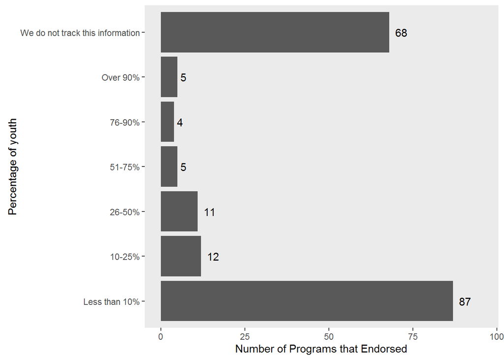